# Getting Started with SingleCellComplexHeatMap

XueCheng

2025-06-24

# Introduction

The `SingleCellComplexHeatMap` package provides a powerful and flexible way to visualize single-cell RNA-seq data using complex heatmaps that simultaneously display both gene expression levels (as color intensity) and expression percentages (as circle sizes). This dual-information approach allows for comprehensive visualization of expression patterns across different cell types and conditions.

## Key Features

- **Dual Information Display**: Shows both expression intensity and percentage in a single visualization
- **Gene Grouping**: Organize genes by functional categories with color-coded annotations
- **Time Course Support**: Handle time series data with proper ordering and visualization
- **Cell Type Annotations**: Annotate and group different cell types
- **Flexible Display Options**: Show/hide different annotation layers
- **Highly Customizable**: Extensive parameters for colors, sizes, fonts, and layouts
- **Seurat Integration**: Direct integration with Seurat objects

# Installation

```r
# Install from GitHub
devtools::install_github("FanXuRong/SingleCellComplexHeatMap")
```

# Quick Start

## Loading Libraries and Data

```r
library(SingleCellComplexHeatMap)
library(Seurat)
library(dplyr)
# Load optional color packages for testing
if (requireNamespace("ggsci", quietly = TRUE)) {
  library(ggsci)
}
if (requireNamespace("viridis", quietly = TRUE)) {
  library(viridis)
}

# For this vignette, we'll use the built-in pbmc_small dataset
data("pbmc_small", package = "SeuratObject")
seurat_obj <- pbmc_small

# Add example metadata for demonstration
set.seed(123)
seurat_obj$timepoint <- sample(c("Mock", "6hpi", "24hpi"), ncol(seurat_obj), replace = TRUE)
seurat_obj$celltype <- sample(c("T_cell", "B_cell", "Monocyte"), ncol(seurat_obj), replace = TRUE)
seurat_obj$group <- paste(seurat_obj$timepoint, seurat_obj$celltype, sep = "_")

# Check the structure
head(seurat_obj@meta.data)
```

```
#>                   orig.ident nCount_RNA nFeature_RNA RNA_snn_res.0.8
#> ATGCCAGAACGACT SeuratProject         70           47               0
#> CATGGCCTGTGCAT SeuratProject         85           52               0
#> GAACCTGATGAACC SeuratProject         87           50               1
#> TGACTGGATTCTCA SeuratProject        127           56               0
#> AGTCAGACTGCACA SeuratProject        173           53               0
#> TCTGATACACGTGT SeuratProject         70           48               0
#>                letter.idents groups RNA_snn_res.1 timepoint celltype
#> ATGCCAGAACGACT             A     g2             0     24hpi   B_cell
#> CATGGCCTGTGCAT             A     g1             0     24hpi Monocyte
#> GAACCTGATGAACC             B     g2             0     24hpi Monocyte
#> TGACTGGATTCTCA             A     g2             0      6hpi   T_cell
#> AGTCAGACTGCACA             A     g2             0     24hpi   B_cell
#> TCTGATACACGTGT             A     g1             0      6hpi   T_cell
#>                         group
#> ATGCCAGAACGACT   24hpi_B_cell
#> CATGGCCTGTGCAT 24hpi_Monocyte
#> GAACCTGATGAACC 24hpi_Monocyte
#> TGACTGGATTCTCA    6hpi_T_cell
#> AGTCAGACTGCACA   24hpi_B_cell
#> TCTGATACACGTGT    6hpi_T_cell
```

## Basic Usage

The simplest way to create a complex heatmap is to provide a Seurat object and a list of features:

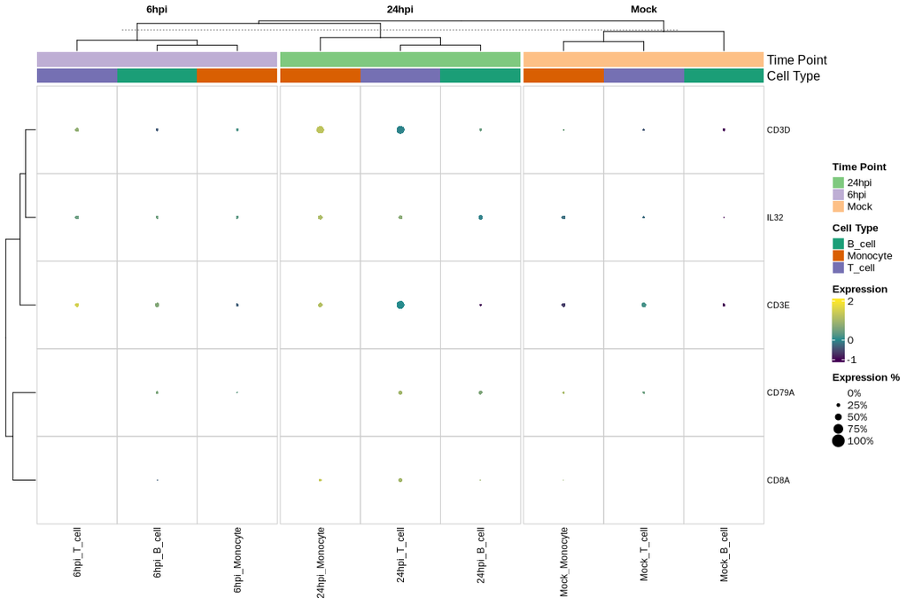

```r
# Define genes to visualize
features <- c("CD3D", "CD3E", "CD8A", "IL32", "CD79A")

# Create basic heatmap
heatmap_basic <- create_single_cell_complex_heatmap(
  seurat_object = seurat_obj,
  features = features,
  group_by = "group"
)
```

## Advanced Usage with Gene Grouping

For more complex analyses, you can group genes by functional categories:

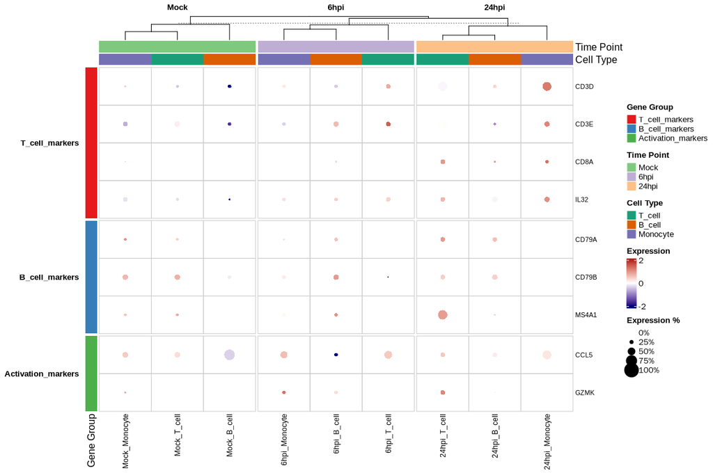

```r
# Define gene groups
gene_groups <- list(
  "T_cell_markers" = c("CD3D", "CD3E", "CD8A", "IL32"),
  "B_cell_markers" = c("CD79A", "CD79B", "MS4A1"),
  "Activation_markers" = c("GZMK", "CCL5")
)

# Get all genes from groups
all_genes <- c("CD3D", "CD3E", "CD8A", "IL32","CD79A", "CD79B", "MS4A1","GZMK", "CCL5")

# Create advanced heatmap with gene grouping
heatmap_advanced <- create_single_cell_complex_heatmap(
  seurat_object = seurat_obj,
  features = all_genes,
  gene_classification = gene_groups,
  group_by = "group",
  time_points_order = c("Mock", "6hpi", "24hpi"),
  cell_types_order = c("T_cell", "B_cell", "Monocyte"),
  color_range = c(-2, 0, 2),
  color_palette = c("navy", "white", "firebrick"),
  max_circle_size = 3,
  split_by = "time"
)
```

# Understanding the Visualization

## Dual Information Display

The complex heatmap displays two types of information simultaneously:

1. **Color Intensity**: Represents the scaled expression level of each gene
2. **Circle Size**: Represents the percentage of cells expressing each gene

This dual approach allows you to distinguish between genes that are: - Highly expressed in few cells (small intense circles) - Moderately expressed in many cells (large moderate circles) - Highly expressed in many cells (large intense circles)

## Data Preparation Requirements

For optimal functionality, your group identifiers should follow the format `"timepoint_celltype"`:

```r
# Example of proper data preparation
seurat_obj@meta.data <- seurat_obj@meta.data %>%
  mutate(
    # Create combined group for time course + cell type analysis
    time_celltype = paste(timepoint, celltype, sep = "_"),

    # Or create other combinations as needed
    cluster_time = paste(RNA_snn_res.0.8, timepoint, sep = "_")
  )

head(seurat_obj@meta.data[, c("timepoint", "celltype", "time_celltype","cluster_time")])
```

```
#>                timepoint celltype  time_celltype cluster_time
#> ATGCCAGAACGACT     24hpi   B_cell   24hpi_B_cell      0_24hpi
#> CATGGCCTGTGCAT     24hpi Monocyte 24hpi_Monocyte      0_24hpi
#> GAACCTGATGAACC     24hpi Monocyte 24hpi_Monocyte      1_24hpi
#> TGACTGGATTCTCA      6hpi   T_cell    6hpi_T_cell       0_6hpi
#> AGTCAGACTGCACA     24hpi   B_cell   24hpi_B_cell      0_24hpi
#> TCTGATACACGTGT      6hpi   T_cell    6hpi_T_cell       0_6hpi
```

# Customization Options

## Custom Annotation Titles

Here, we test the ability to change the default titles for the annotation tracks.

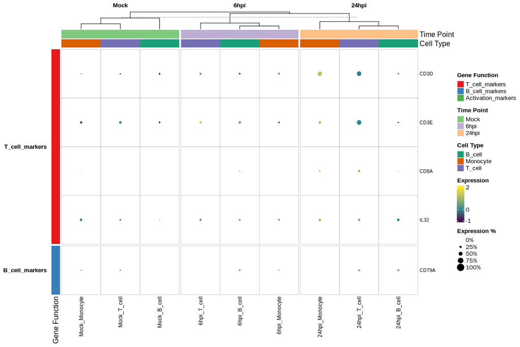

```r
heatmap <- create_single_cell_complex_heatmap(
  seurat_object = seurat_obj,
  features = features,
  gene_classification = gene_groups,
  group_by = "group",
  time_points_order = c("Mock", "6hpi", "24hpi"),

  # NEW: Custom annotation titles
  gene_group_title = "Gene Function",
  time_point_title = "Time Point",
  cell_type_title = "Cell Type",

  split_by = "time"
)
```

## Color Schemes

You can customize colors for different components:

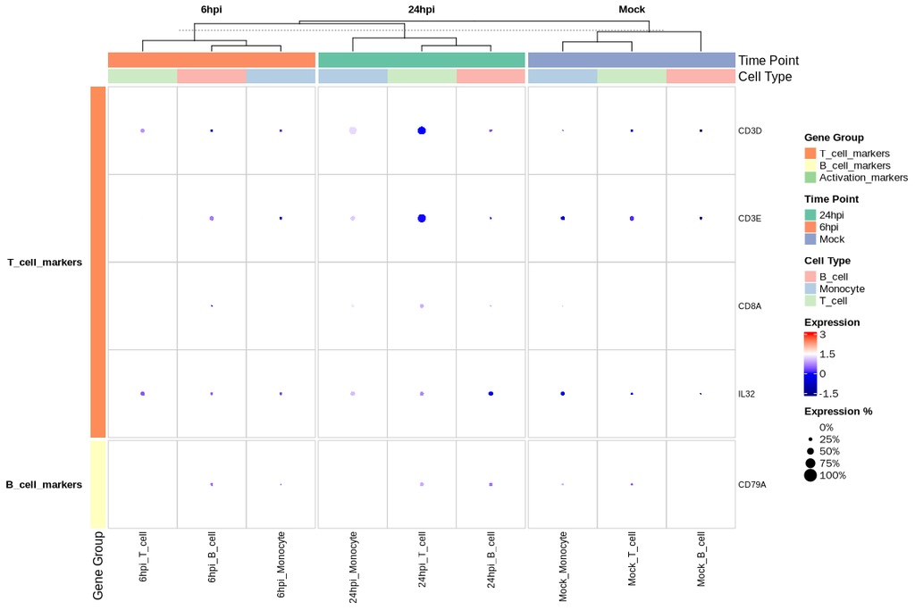

```r
# Custom color schemes
heatmap_colors <- create_single_cell_complex_heatmap(
  seurat_object = seurat_obj,
  features = features,
  gene_classification = gene_groups,
  group_by = "group",
  color_range = c(-1.5, 0, 1.5,3),  # 4-point gradient
  color_palette = c("darkblue", "blue", "white", "red"), # 4 colors
  gene_color_palette = "Spectral",
  time_color_palette = "Set2",
  celltype_color_palette = "Pastel1"
)
```